# Part A - Signal Strength Quality Prediction

## PROJECT OBJECTIVE: To build a classifier which can use the given parameters to determine the signal strength or quality.

### Part A - 30 Marks

### DOMAIN: Electronics and Telecommunication

CONTEXT: A communications equipment manufacturing company has a product which is responsible for emitting informative signals. Company wants to build a machine learning model which can help the company to predict the equipment’s signal quality using various parameters.

DATA DESCRIPTION: The data set contains information on various signal tests performed:

1. Parameters: Various measurable signal parameters.
2. Signal_Quality: Final signal strength or quality

### 1. Data import and Understanding [10 Marks]

#### A. Read the ‘Signals.csv’ as DataFrame and import required libraries. [2 Marks]

```python
# Import All Dependencies

import numpy as np
import pandas as pd
import seaborn as sns
import scipy.stats as stats
import matplotlib.pyplot as plt
from tensorflow import keras
from sklearn.model_selection import StratifiedKFold
from sklearn.model_selection import train_test_split
from sklearn.preprocessing import StandardScaler, MinMaxScaler
import pickle
from tensorflow.keras.utils import to_categorical
from tensorflow.keras.models import Sequential
from tensorflow.keras.layers import Flatten, Dense
from tensorflow.keras import regularizers, optimizers
from sklearn.metrics import r2_score
from tensorflow.keras.models import load_model
import warnings
import random
from tensorflow.keras.layers import LeakyReLU
from tensorflow.keras.utils import to_categorical
from sklearn.metrics import confusion_matrix , accuracy_score, classification_report

seed = 7
np.random.seed(seed)
warnings.filterwarnings("ignore")
%matplotlib inline
```

```python
#Read the data as a data frame
df = pd.read_csv('NN Project Data - Signal.csv')
print("Total Shape: {}".format(df.shape))
df.head(5)
```

```
Total Shape: (1599, 12)
```

|  | Parameter 1 | Parameter 2 | Parameter 3 | Parameter 4 | Parameter 5 | Parameter 6 | Parameter 7 | Parameter 8 | Parameter 9 | Parameter 10 | Parameter 11 | Signal_Strength |
| --- | --- | --- | --- | --- | --- | --- | --- | --- | --- | --- | --- | --- |
| 0 | 7.4 | 0.70 | 0.00 | 1.9 | 0.076 | 11.0 | 34.0 | 0.9978 | 3.51 | 0.56 | 9.4 | 5 |
| 1 | 7.8 | 0.88 | 0.00 | 2.6 | 0.098 | 25.0 | 67.0 | 0.9968 | 3.20 | 0.68 | 9.8 | 5 |
| 2 | 7.8 | 0.76 | 0.04 | 2.3 | 0.092 | 15.0 | 54.0 | 0.9970 | 3.26 | 0.65 | 9.8 | 5 |
| 3 | 11.2 | 0.28 | 0.56 | 1.9 | 0.075 | 17.0 | 60.0 | 0.9980 | 3.16 | 0.58 | 9.8 | 6 |
| 4 | 7.4 | 0.70 | 0.00 | 1.9 | 0.076 | 11.0 | 34.0 | 0.9978 | 3.51 | 0.56 | 9.4 | 5 |

#### B. Check for missing values and print percentage for each attribute. [2 Marks]

```python
# function to check missing data

def missing_data(df):
    """
    Objective
    ----------
    it shows the missing data in each column with
    total missing values, percentage of missing value and
    its data type in descending order.

    parameters
    ----------
    df: pandas dataframe
        input data frame

    returns
    ----------
    missing_data: output data frame(pandas dataframe)

    """

    total = df.isnull().sum().sort_values(ascending=False)

    percent = round((df.isnull().sum()/df.isnull().count()  * 100).sort_values(ascending=False),2)

    data_type = df.dtypes
    missing_data = pd.concat([total,percent,data_type],
                             axis=1,
                             keys=['Total','Percent','Data_Type']).sort_values("Total",
                                                                               axis = 0,
                                                                               ascending = False)

    return missing_data
```

```python
missing_data(df)
```

|  | Total | Percent | Data_Type |
| --- | --- | --- | --- |
| Parameter 1 | 0 | 0.0 | float64 |
| Parameter 2 | 0 | 0.0 | float64 |
| Parameter 3 | 0 | 0.0 | float64 |
| Parameter 4 | 0 | 0.0 | float64 |
| Parameter 5 | 0 | 0.0 | float64 |
| Parameter 6 | 0 | 0.0 | float64 |
| Parameter 7 | 0 | 0.0 | float64 |
| Parameter 8 | 0 | 0.0 | float64 |
| Parameter 9 | 0 | 0.0 | float64 |
| Parameter 10 | 0 | 0.0 | float64 |
| Parameter 11 | 0 | 0.0 | float64 |
| Signal_Strength | 0 | 0.0 | int64 |

- There are no null values in the data

#### C. Check for presence of duplicate records in the dataset and impute with appropriate method. [2 Marks]

```python
# check duplicates and remove if present
def drop_duplicates(df):
    """
    Objective
    ----------
    Drop duplicates rows in data frame except for the first occurrence.

    parameters
    ----------
    df: pandas dataframe
        input data frame

    returns
    ----------
    dataframe with all unique rows
    """

    try:
        dr = df.duplicated().value_counts()[1]
        print("[INFO] Dropping {} duplicates records...".format(dr))
        f_df = df.drop_duplicates(keep="first")

        return f_df
    except KeyError:
        print("[INFO] No duplicates records found")
        return df
```

```python
df = drop_duplicates(df)
```

```
[INFO] Dropping 240 duplicates records...
```

- found 240 duplicates records so we can drop those records and keep the first records for reference

#### D. Visualise distribution of the target variable. [2 Marks]

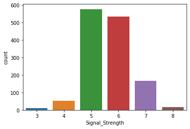

```python
sns.countplot(df['Signal_Strength'])    # Distibution of the column 'Signal_Strength'
plt.show()
```

- class 5 and 6 in 'Signal_Strength' has the highest count.

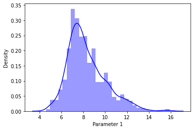

```
--------Distribution of Parameter 1 ----------------
Mean is: 8.310596026490087
Median is: 7.9
Mode is: 0    7.2
dtype: float64
Standard deviation is: 1.736989807532466
Skewness is: 0.9410413664561449
Maximum is: 15.9
Minimum is: 4.6

---------------------------------
```

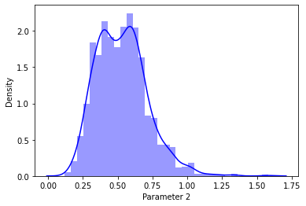

```
--------Distribution of Parameter 2 ----------------
Mean is: 0.5294775570272258
Median is: 0.52
Mode is: 0    0.5
dtype: float64
Standard deviation is: 0.18303131761907185
Skewness is: 0.7292789463991854
Maximum is: 1.58
Minimum is: 0.12

---------------------------------
```

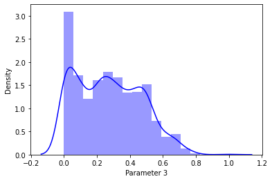

```
--------Distribution of Parameter 3 ----------------
Mean is: 0.27233259749815975
Median is: 0.26
Mode is: 0    0.0
dtype: float64
Standard deviation is: 0.1955365445504639
Skewness is: 0.31272554238899036
Maximum is: 1.0
Minimum is: 0.0

---------------------------------
```

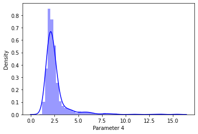

```
--------Distribution of Parameter 4 ----------------
Mean is: 2.523399558498897
Median is: 2.2
Mode is: 0    2.0
dtype: float64
Standard deviation is: 1.3523137577104198
Skewness is: 4.548153403940447
Maximum is: 15.5
Minimum is: 0.9

---------------------------------
```

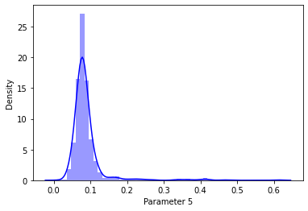

```
--------Distribution of Parameter 5 ----------------
Mean is: 0.0881236203090504
Median is: 0.079
Mode is: 0    0.08
dtype: float64
Standard deviation is: 0.04937686244348626
Skewness is: 5.502487294623722
Maximum is: 0.611
Minimum is: 0.012

---------------------------------
```

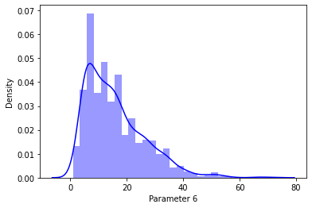

```
--------Distribution of Parameter 6 ----------------
Mean is: 15.893303899926417
Median is: 14.0
Mode is: 0    6.0
dtype: float64
Standard deviation is: 10.447270259048695
Skewness is: 1.2265794991760643
Maximum is: 72.0
Minimum is: 1.0

---------------------------------
```

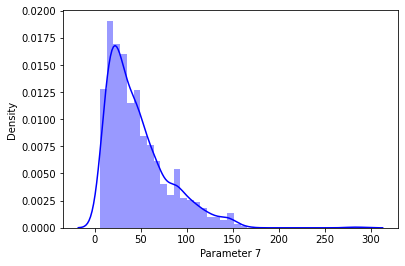

```
--------Distribution of Parameter 7 ----------------
Mean is: 46.82597498160412
Median is: 38.0
Mode is: 0    28.0
dtype: float64
Standard deviation is: 33.40894570661654
Skewness is: 1.5403680777213933
Maximum is: 289.0
Minimum is: 6.0

---------------------------------
```

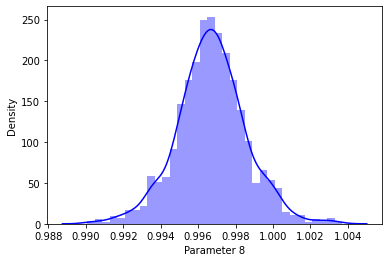

```
--------Distribution of Parameter 8 ----------------
Mean is: 0.9967089477557026
Median is: 0.9967
Mode is: 0    0.9968
dtype: float64
Standard deviation is: 0.0018689171325591398
Skewness is: 0.04477785573116107
Maximum is: 1.00369
Minimum is: 0.99007

---------------------------------
```

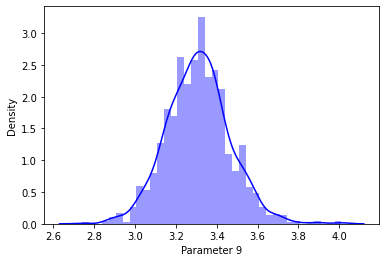

```
--------Distribution of Parameter 9 ----------------
Mean is: 3.309786607799856
Median is: 3.31
Mode is: 0    3.3
dtype: float64
Standard deviation is: 0.15503631128729595
Skewness is: 0.2320322752014824
Maximum is: 4.01
Minimum is: 2.74

---------------------------------
```

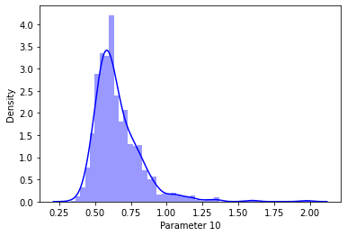

```
--------Distribution of Parameter 10 ----------------
Mean is: 0.6587049300956593
Median is: 0.62
Mode is: 0    0.54
dtype: float64
Standard deviation is: 0.17066689057420695
Skewness is: 2.4065046145674196
Maximum is: 2.0
Minimum is: 0.33

---------------------------------
```

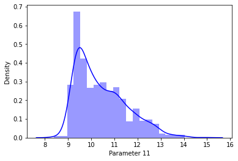

```
--------Distribution of Parameter 11 ----------------
Mean is: 10.432315428013228
Median is: 10.2
Mode is: 0    9.5
dtype: float64
Standard deviation is: 1.0820654499497833
Skewness is: 0.8598411692319623
Maximum is: 14.9
Minimum is: 8.4

---------------------------------
```

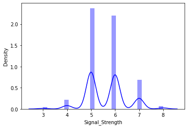

```
--------Distribution of Signal_Strength ----------------
Mean is: 5.6232523914643116
Median is: 6.0
Mode is: 0    5
dtype: int64
Standard deviation is: 0.8235780017165619
Skewness is: 0.19240658731658308
Maximum is: 8
Minimum is: 3

---------------------------------
```

```python
# studying the distribution of continuous attributes
cols = list(df)
for i in np.arange(len(cols)):
    sns.distplot(df[cols[i]], color='blue')
    #plt.xlabel('Experience')
    plt.show()

    print('--------Distribution of {} ----------------  '.format(cols[i]))
    print('Mean is:',df[cols[i]].mean())
    print('Median is:',df[cols[i]].median())
    print('Mode is:',df[cols[i]].mode())
    print('Standard deviation is:',df[cols[i]].std())
    print('Skewness is:',df[cols[i]].skew())
    print('Maximum is:',df[cols[i]].max())
    print('Minimum is:',df[cols[i]].min())
    print()
    print("---------------------------------")
```

#### E. Share insights from the initial data analysis (at least 2). [2 Marks]

##### Data Analysis

**i. Data Info**

```python
# 1. Data type of each attribute
df.info()   # it gives information about the data and data types of each attribute
```

```
<class 'pandas.core.frame.DataFrame'>
Int64Index: 1359 entries, 0 to 1598
Data columns (total 12 columns):
 #   Column           Non-Null Count  Dtype
---  ------           --------------  -----
 0   Parameter 1      1359 non-null   float64
 1   Parameter 2      1359 non-null   float64
 2   Parameter 3      1359 non-null   float64
 3   Parameter 4      1359 non-null   float64
 4   Parameter 5      1359 non-null   float64
 5   Parameter 6      1359 non-null   float64
 6   Parameter 7      1359 non-null   float64
 7   Parameter 8      1359 non-null   float64
 8   Parameter 9      1359 non-null   float64
 9   Parameter 10     1359 non-null   float64
 10  Parameter 11     1359 non-null   float64
 11  Signal_Strength  1359 non-null   int64
dtypes: float64(11), int64(1)
memory usage: 170.3 KB
```

**ii. 5 point summary**

```python
# 2 . 5 point summary of numerical attributes
df.describe()
```

|  | Parameter 1 | Parameter 2 | Parameter 3 | Parameter 4 | Parameter 5 | Parameter 6 | Parameter 7 | Parameter 8 | Parameter 9 | Parameter 10 | Parameter 11 | Signal_Strength |
| --- | --- | --- | --- | --- | --- | --- | --- | --- | --- | --- | --- | --- |
| count | 1359.000000 | 1359.000000 | 1359.000000 | 1359.000000 | 1359.000000 | 1359.000000 | 1359.000000 | 1359.000000 | 1359.000000 | 1359.000000 | 1359.000000 | 1359.000000 |
| mean | 8.310596 | 0.529478 | 0.272333 | 2.523400 | 0.088124 | 15.893304 | 46.825975 | 0.996709 | 3.309787 | 0.658705 | 10.432315 | 5.623252 |
| std | 1.736990 | 0.183031 | 0.195537 | 1.352314 | 0.049377 | 10.447270 | 33.408946 | 0.001869 | 0.155036 | 0.170667 | 1.082065 | 0.823578 |
| min | 4.600000 | 0.120000 | 0.000000 | 0.900000 | 0.012000 | 1.000000 | 6.000000 | 0.990070 | 2.740000 | 0.330000 | 8.400000 | 3.000000 |
| 25% | 7.100000 | 0.390000 | 0.090000 | 1.900000 | 0.070000 | 7.000000 | 22.000000 | 0.995600 | 3.210000 | 0.550000 | 9.500000 | 5.000000 |
| 50% | 7.900000 | 0.520000 | 0.260000 | 2.200000 | 0.079000 | 14.000000 | 38.000000 | 0.996700 | 3.310000 | 0.620000 | 10.200000 | 6.000000 |
| 75% | 9.200000 | 0.640000 | 0.430000 | 2.600000 | 0.091000 | 21.000000 | 63.000000 | 0.997820 | 3.400000 | 0.730000 | 11.100000 | 6.000000 |
| max | 15.900000 | 1.580000 | 1.000000 | 15.500000 | 0.611000 | 72.000000 | 289.000000 | 1.003690 | 4.010000 | 2.000000 | 14.900000 | 8.000000 |

**iii. correlation between the attributes**

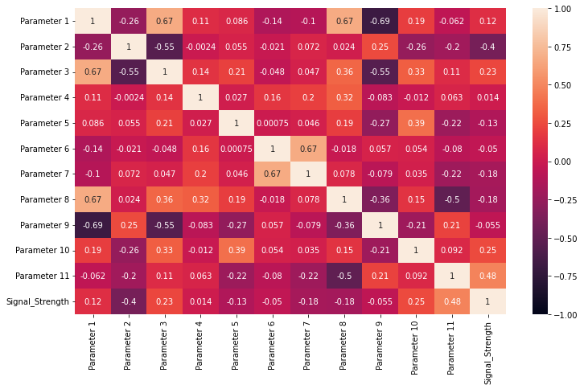

```python
# 3. studying correlation between the attributes
b_corr=df.corr()
plt.subplots(figsize =(12, 7))
sns.heatmap(b_corr,annot=True, vmax=1.0, vmin=-1.0)
plt.show()
```

- Since high correlation coefficient value lies between ± 0.50 and ± 1 Parameter 1 is highly correlated with Parameter 3 and Parameter 8, Parameter 9. Parameter 6 and 7 are highly correlated. But since, the correlation is not too high near 0.8 or above not dropping the features.

**iv. Presence of outliers**

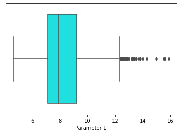

```
--------------- Boxplot of Parameter 1 ---------------
Q1 is :  7.1
Q2 is :  7.9
Q3 is :  9.2
IQR is: 2.0999999999999996
Lower Whisker, Upper Whisker :  3.95 , 12.349999999999998
Out of  1359  rows in data, number of outliers are: 41

---------------------------------
```

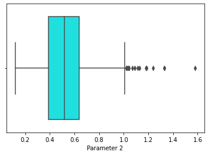

```
--------------- Boxplot of Parameter 2 ---------------
Q1 is :  0.39
Q2 is :  0.52
Q3 is :  0.64
IQR is: 0.25
Lower Whisker, Upper Whisker :  0.015000000000000013 , 1.0150000000000001
Out of  1359  rows in data, number of outliers are: 19

---------------------------------
```

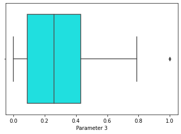

```
--------------- Boxplot of Parameter 3 ---------------
Q1 is :  0.09
Q2 is :  0.26
Q3 is :  0.43
IQR is: 0.33999999999999997
Lower Whisker, Upper Whisker :  -0.42000000000000004 , 0.94
Out of  1359  rows in data, number of outliers are: 1

---------------------------------
```

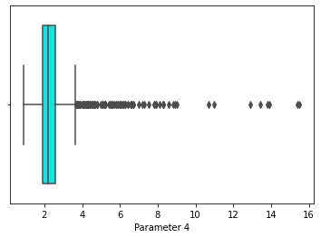

```
--------------- Boxplot of Parameter 4 ---------------
Q1 is :  1.9
Q2 is :  2.2
Q3 is :  2.6
IQR is: 0.7000000000000002
Lower Whisker, Upper Whisker :  0.8499999999999996 , 3.6500000000000004
Out of  1359  rows in data, number of outliers are: 126

---------------------------------
```

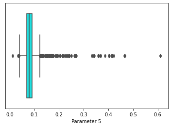

```
--------------- Boxplot of Parameter 5 ---------------
Q1 is :  0.07
Q2 is :  0.079
Q3 is :  0.091
IQR is: 0.02099999999999999
Lower Whisker, Upper Whisker :  0.03850000000000002 , 0.12249999999999998
Out of  1359  rows in data, number of outliers are: 87

---------------------------------
```

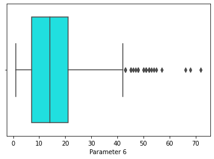

```
--------------- Boxplot of Parameter 6 ---------------
Q1 is :  7.0
Q2 is :  14.0
Q3 is :  21.0
IQR is: 14.0
Lower Whisker, Upper Whisker :  -14.0 , 42.0
Out of  1359  rows in data, number of outliers are: 26

---------------------------------
```

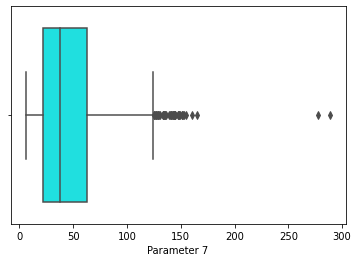

```
--------------- Boxplot of Parameter 7 ---------------
Q1 is :  22.0
Q2 is :  38.0
Q3 is :  63.0
IQR is: 41.0
Lower Whisker, Upper Whisker :  -39.5 , 124.5
Out of  1359  rows in data, number of outliers are: 45

---------------------------------
```

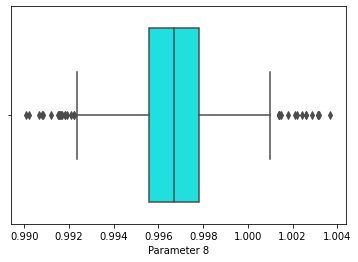

```
--------------- Boxplot of Parameter 8 ---------------
Q1 is :  0.9956
Q2 is :  0.9967
Q3 is :  0.99782
IQR is: 0.0022199999999999998
Lower Whisker, Upper Whisker :  0.99227 , 1.00115
Out of  1359  rows in data, number of outliers are: 35

---------------------------------
```

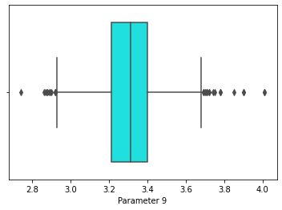

```
--------------- Boxplot of Parameter 9 ---------------
Q1 is :  3.21
Q2 is :  3.31
Q3 is :  3.4
IQR is: 0.18999999999999995
Lower Whisker, Upper Whisker :  2.925 , 3.6849999999999996
Out of  1359  rows in data, number of outliers are: 28

---------------------------------
```

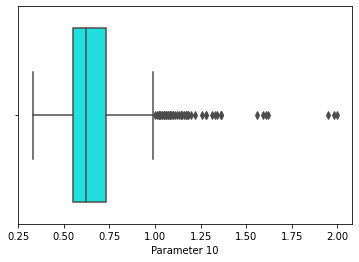

```
--------------- Boxplot of Parameter 10 ---------------
Q1 is :  0.55
Q2 is :  0.62
Q3 is :  0.73
IQR is: 0.17999999999999994
Lower Whisker, Upper Whisker :  0.28000000000000014 , 0.9999999999999999
Out of  1359  rows in data, number of outliers are: 55

---------------------------------
```

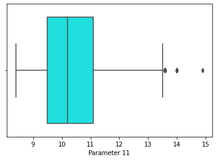

```
--------------- Boxplot of Parameter 11 ---------------
Q1 is :  9.5
Q2 is :  10.2
Q3 is :  11.1
IQR is: 1.5999999999999996
Lower Whisker, Upper Whisker :  7.1000000000000005 , 13.5
Out of  1359  rows in data, number of outliers are: 12

---------------------------------
```

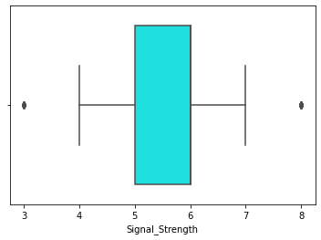

```
--------------- Boxplot of Signal_Strength ---------------
Q1 is :  5.0
Q2 is :  6.0
Q3 is :  6.0
IQR is: 1.0
Lower Whisker, Upper Whisker :  3.5 , 7.5
Out of  1359  rows in data, number of outliers are: 27

---------------------------------
```

```python
# 4. Checking the presence of outliers
l = len(df)
col = list(df.columns)
#col.remove('condition')
for i in np.arange(len(col)):
    sns.boxplot(x= df[col[i]], color='cyan')
    plt.show()
    print('--------------- Boxplot of {} ---------------'.format(col[i]))
    #calculating the outiers in attribute
    Q1 = df[col[i]].quantile(0.25)
    Q2 = df[col[i]].quantile(0.50)
    Q3 = df[col[i]].quantile(0.75)
    IQR = Q3 - Q1
    L_W = (Q1 - 1.5 *IQR)
    U_W = (Q3 + 1.5 *IQR)
    print('Q1 is : ',Q1)
    print('Q2 is : ',Q2)
    print('Q3 is : ',Q3)
    print('IQR is:',IQR)
    print('Lower Whisker, Upper Whisker : ',L_W,',',U_W)
    bools = (df[col[i]] < (Q1 - 1.5 *IQR)) |(df[col[i]] > (Q3 + 1.5 * IQR))
    print('Out of ',l,' rows in data, number of outliers are:',bools.sum())   #calculating the number of outliers
    print()
    print("---------------------------------")
```

### 2. Data preprocessing [7 Marks]

#### A. Split the data into X & Y. [1 Marks]

```python
X = df.drop("Signal_Strength", axis=1) # all independent variables
y = df['Signal_Strength'] # dependent variables
print("X shape: {}".format(X.shape))
print("y shape: {}".format(y.shape))
```

```
X shape: (1359, 11)
y shape: (1359,)
```

#### B. Split the data into train & test with 70:30 proportion.[1 Marks]

```python
# splitting to create test data
X_train, X_test, y_train, y_test = train_test_split(X,
                                                      y,
                                                      test_size=0.30,
                                                      random_state=seed)
```

#### C. Print shape of all the 4 variables and verify if train and test data is in sync. [1 Marks]

```python
print("Shape for X_train: {}".format(X_train.shape))
print("Shape for y_train: {}".format(y_train.shape))
print("Shape for X_test: {}".format(X_test.shape))
print("Shape for y_test: {}".format(y_test.shape))
```

```
Shape for X_train: (951, 11)
Shape for y_train: (951,)
Shape for X_test: (408, 11)
Shape for y_test: (408,)
```

- train and test data splited into accurate 70:30 proportion

#### D. Normalise the train and test data with appropriate method. [2 Marks]

```python
# normalize the data using MinMax Normalization Technique
mm_scaler = MinMaxScaler()

# transform on train data then fit on train and test data
X_train_scale = mm_scaler.fit_transform(X_train)
X_test_scale = mm_scaler.transform(X_test)
```

#### E. Transform Labels into format acceptable by Neural Network [2 Marks]

```python
# create a dic to map labes to sequence number
mapping_dict = {3: 0, 4: 1, 5: 2, 6: 3, 7: 4, 8: 5}
reversed_maping_dict = {v: k for k, v in mapping_dict.items()}

print(mapping_dict)
print(reversed_maping_dict)
```

```
{3: 0, 4: 1, 5: 2, 6: 3, 7: 4, 8: 5}
{0: 3, 1: 4, 2: 5, 3: 6, 4: 7, 5: 8}
```

```python
y_train_maped =  y_train.map(mapping_dict)
y_test_maped = y_test.map(mapping_dict)
```

```python
# convert the labels from integers/categories to vectors
trainY = to_categorical(y_train_maped, num_classes=6)
testY = to_categorical(y_test_maped, num_classes=6)
```

```python
y_train_maped.iloc[41]
```

```
5
```

```python
trainY[41]
```

```
array([0., 0., 0., 0., 0., 1.], dtype=float32)
```

- labes are not in sequence so we mapped the labels with there sequence values so that we can convert it to one hot encoder
- now we have converted eg. 8 -> 5 and that 5 is respresented by vector [0., 0., 0., 0., 0., 1.]

### 3. Model Training & Evaluation using Neural Network [13 Marks]

#### A. Design a Neural Network to train a classifier. [3 Marks]

```python
Model1 = Sequential()

# Adding the input layer and the first hidden layer
Model1.add(Dense(units = 400,
                     kernel_initializer = 'uniform',
                     activation = 'relu',
                     input_shape = [X_train_scale.shape[1]]))


# Adding the second hidden layer
Model1.add(Dense(units = 600,
                 kernel_initializer = 'uniform'))
Model1.add(LeakyReLU(alpha=0.1))

# Adding the Third hidden layer
Model1.add(Dense(units = 1000,
                 kernel_initializer = 'uniform'))
Model1.add(LeakyReLU(alpha=0.1))

# Adding the fourth hidden layer
Model1.add(Dense(units = 1200,
                 kernel_initializer = 'uniform'))
Model1.add(LeakyReLU(alpha=0.1))

# Adding the fifth hidden layer
Model1.add(Dense(units = 1800,
                 kernel_initializer = 'uniform',
                 activation = 'relu'))

# Adding the output layer
Model1.add(Dense(units = 6,
                 kernel_initializer = 'uniform',
                 activation = 'softmax'))
```

```python
# Compile the network :
Model1.compile(optimizer = 'adam',
                         loss = 'categorical_crossentropy',
                         metrics=["accuracy"])


Model1.summary()
```

```
Model: "sequential"
_________________________________________________________________
 Layer (type)                Output Shape              Param #
=================================================================
 dense (Dense)               (None, 400)               4800

 dense_1 (Dense)             (None, 600)               240600

 leaky_re_lu (LeakyReLU)     (None, 600)               0

 dense_2 (Dense)             (None, 1000)              601000

 leaky_re_lu_1 (LeakyReLU)   (None, 1000)              0

 dense_3 (Dense)             (None, 1200)              1201200

 leaky_re_lu_2 (LeakyReLU)   (None, 1200)              0

 dense_4 (Dense)             (None, 1800)              2161800

 dense_5 (Dense)             (None, 6)                 10806

=================================================================
Total params: 4,220,206
Trainable params: 4,220,206
Non-trainable params: 0
_________________________________________________________________
```

#### B. Train the classifier using previously designed Architecture [2 Marks]

```python
# Fitting the ANN to the Training set

EPOCHS = 200

history_1 = Model1.fit(X_train_scale,
                          trainY,
                          batch_size=128 ,
                          epochs=EPOCHS ,
                          validation_split=0.1,
                          verbose = 1)

# save trained model
Model1.save("Classification_Model_1.h5")
```

[output not shown]

#### C. Plot 2 separate visuals. [3 Marks]

- i. Training Loss and Validation Loss

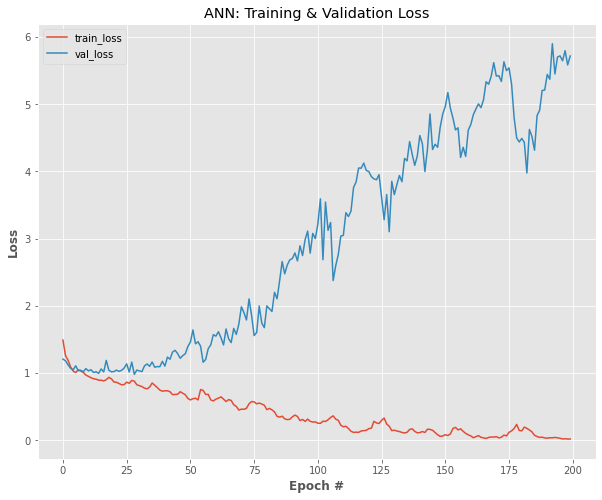

```python
# plot the training and validation loss
N = np.arange(0, EPOCHS)
plt.style.use("ggplot")
plt.figure(figsize = [10,8])
plt.plot(N, history_1.history["loss"], label="train_loss")
plt.plot(N, history_1.history["val_loss"], label="val_loss")
plt.title("ANN: Training & Validation Loss")
plt.xlabel("Epoch #", weight="bold")
plt.ylabel("Loss", weight="bold")
plt.legend()
plt.show()
```

- ii. Training Accuracy and Validation Accuracy

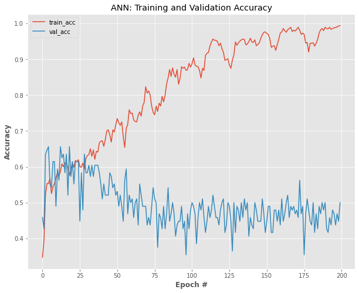

```python
# plot the training and validation accuracy
N = np.arange(0, EPOCHS)
plt.style.use("ggplot")
plt.figure(figsize = [10,8])
plt.plot(N, history_1.history["accuracy"], label="train_acc")
plt.plot(N, history_1.history["val_accuracy"], label="val_acc")
plt.title("ANN: Training and Validation Accuracy")
plt.xlabel("Epoch #", weight="bold")
plt.ylabel("Accuracy", weight="bold")
plt.legend()
plt.show()
```

#### D. Design new architecture/update existing architecture in attempt to improve the performance of the model. [2 Marks]

```python
Model2 = Sequential()

# The Input Layer :
Model2.add(Dense(units=128,
                   kernel_initializer='normal',
                   input_dim = X_train_scale.shape[1],
                   activation='relu'))

# The Hidden Layers :
Model2.add(Dense(units=64,
                   kernel_initializer='normal',
                   activation='relu'))

Model2.add(Dense(units=32,
                   kernel_initializer='normal'))
Model2.add(LeakyReLU(alpha=0.1))

Model2.add(Dense(units=16,
                   kernel_initializer='normal'))
Model2.add(LeakyReLU(alpha=0.1))


# The Output Layer :
Model2.add(Dense(units=6,
                   kernel_initializer='normal',
                   activation="softmax"))  # this is regression so will use linear activation function
```

```python
# Compile the network :
Model2.compile(optimizer = 'adam',
                 loss = 'categorical_crossentropy',
                 metrics=["accuracy"])


Model2.summary()
```

```
Model: "sequential_1"
_________________________________________________________________
 Layer (type)                Output Shape              Param #
=================================================================
 dense_6 (Dense)             (None, 128)               1536

 dense_7 (Dense)             (None, 64)                8256

 dense_8 (Dense)             (None, 32)                2080

 leaky_re_lu_3 (LeakyReLU)   (None, 32)                0

 dense_9 (Dense)             (None, 16)                528

 leaky_re_lu_4 (LeakyReLU)   (None, 16)                0

 dense_10 (Dense)            (None, 6)                 102

=================================================================
Total params: 12,502
Trainable params: 12,502
Non-trainable params: 0
_________________________________________________________________
```

```python
# Fitting the ANN to the Training set

EPOCHS = 200

history_2 = Model2.fit(X_train_scale,
                      trainY,
                      batch_size=62 ,
                      epochs=EPOCHS ,
                      validation_split=0.1,
                      verbose = 1)

# save trained model
Model2.save("Classification_Model_2.h5")
```

[output not shown]

#### E. Plot visuals as in Q3.C and share insights about difference observed in both the models. [3 Marks]

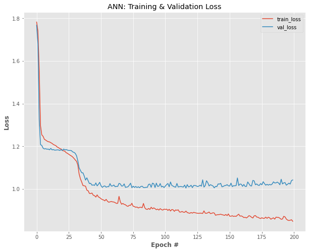

```python
# plot the training and validation loss
N = np.arange(0, EPOCHS)
plt.style.use("ggplot")
plt.figure(figsize = [10,8])
plt.plot(N, history_2.history["loss"], label="train_loss")
plt.plot(N, history_2.history["val_loss"], label="val_loss")
plt.title("ANN: Training & Validation Loss")
plt.xlabel("Epoch #", weight="bold")
plt.ylabel("Loss", weight="bold")
plt.legend()
plt.show()
```

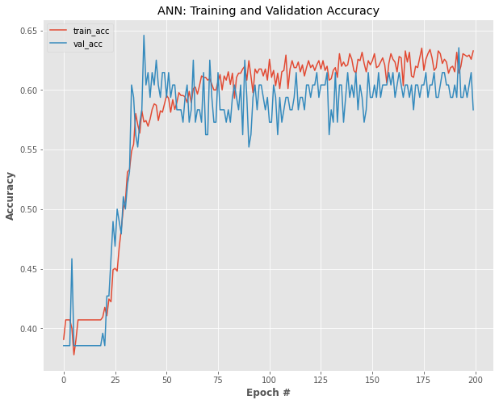

```python
# plot the training and validation accuracy
N = np.arange(0, EPOCHS)
plt.style.use("ggplot")
plt.figure(figsize = [10,8])
plt.plot(N, history_2.history["accuracy"], label="train_acc")
plt.plot(N, history_2.history["val_accuracy"], label="val_acc")
plt.title("ANN: Training and Validation Accuracy")
plt.xlabel("Epoch #", weight="bold")
plt.ylabel("Accuracy", weight="bold")
plt.legend()
plt.show()
```